# Choosing the tuning parameters in t-SNE

Local Continuity Meta-criteria

Pedro Delicado

10 de juni de 2022

## Local Continuity Meta-criteria

Chen and Buja (2009, JASA, Section 3) propose a criteria for tuning parameter selection in ISOMAP: The *Local Continuity Meta-criteria* (or *LC meta-criteria*) that is also useful for other dimensionality reduction methods.

Following the notation used in the classes slides, for a neighborhood size $K'$ and for the $i$-th object $\mathcal{O}_i$ in the data set, let $N_{K'}(i)$ be the number of cases that simultaneously are between the $K'$-nearest neighbors of $\mathcal{O}_i$ in the high-dimensional space (distances here are $\delta_{ij}$), and between the $K'$-nearest neighbors of the mapped point $y_i$ in the low-dimensional configuration (distances here are $\|y_i-y_j\|$). Then define
$$N_{K'}=\frac{1}{n}\sum_{i=1}^n N_{K'}(i)$$
as a global measure of overlapping between $K'$-nearest neighbors in both spaces, that could be called *local continuity*. In order to normalize,
$$M_{K'}=\frac{1}{K'} N_{K'}$$
is used instead of $N_{K'}$ ($M_{K'}$ is always in $[0,1]$). Even better is using the *adjusted LC meta-criteria* defined as
$$M_{K'}^{adj}=M_{K'} - \frac{K'}{n-1},$$
because $K'/(n-1)$ is the expected value of $M_{K'}$ under complete absence of association between the original data and the low-dimensional configuration.

The following function computes $M_{K'}^{adj}$ as a function of two distance matrices between points (one being computed in the high-dimensional space, an the other being the Euclidean distance matrix in the low-dimensional configuration) and the value $K'$.

```r
LCMC <- function(D1,D2,Kp){
  D1 <- as.matrix(D1)
  D2 <- as.matrix(D2)
  n <- dim(D1)[1]
  N.Kp.i <- numeric(n)
  for (i in 1:n){
    N1.i <- sort.int(D1[i,],index.return = TRUE)$ix[1:Kp]
    N2.i <- sort.int(D2[i,],index.return = TRUE)$ix[1:Kp]
    N.Kp.i[i] <- length(intersect(N1.i, N2.i))
  }
  N.Kp<-mean(N.Kp.i)
  M.Kp.adj <- N.Kp/Kp - Kp/(n-1)

  return(list(N.Kp.i=N.Kp.i, M.Kp.adj=M.Kp.adj))
}
```

## Generating the dataset

We are working with a 3-dimensional data set generated around a 1-dimensional S-shape curve. We use the following code to generate the data.

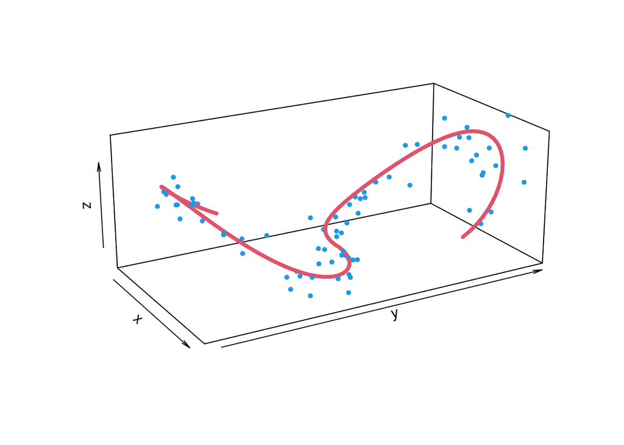

```r
t <- seq(-1.5*pi,1.5*pi,l=100)
R<- 1
n<-75
sd.eps <- .15

set.seed(1)
y <- R*sign(t) - R*sign(t)*cos(t/R)
x <- -R*sin(t/R)
z <- (y/(2*R))^2
rt <- sort(runif(n)*3*pi - 1.5*pi)
eps <- rnorm(n)*sd.eps
ry <- R*sign(rt) - (R+eps)*sign(rt)*cos(rt/R)
rx <- -(R+eps)*sin(rt/R)
rz <- (ry/(2*R))^2 + runif(n,min=-2*sd.eps,max=2*sd.eps)
XYZ <- cbind(rx,ry,rz)

require(plot3D)
lines3D(x,y,z,colvar = NULL,
         phi = 20, theta = 60, r =sqrt(3), d =3, scale=FALSE,
         col=2,lwd=4,as=1,
         xlim=range(rx),ylim=range(ry),zlim=range(rz))
points3D(rx,ry,rz,col=4,pch=19,cex=.6,add=TRUE)
```

## Choosing the tuning parameters in t-SNE

t-SNE depends on two tuning parameters:

- `perplexity`, the effective number of neighbors for each case.
- $q$, the dimension of the desired low-dimensional configuration.

To fit t-SNE, use one of the the R functions `tsne::tsne` or `Rtsne::Rtsne`.

In `tsne::tsne`, the parameters are called `perplexity` and `k` respectively. Moreover, use the default `epoch_callback = NULL` for not calling any callback function. Moreover, use `max_iter = 1000`, `epoch = 1000`.

In `Rtsne::Rtsne`, the parameters are called `perplexity` and `dims` respectively. Moreover, use `theta=0`, `pca=FALSE`, `max_iter = 1000`.

In this assignment, fix $q=1$ and use the function `Rtsne::Rtsne`.

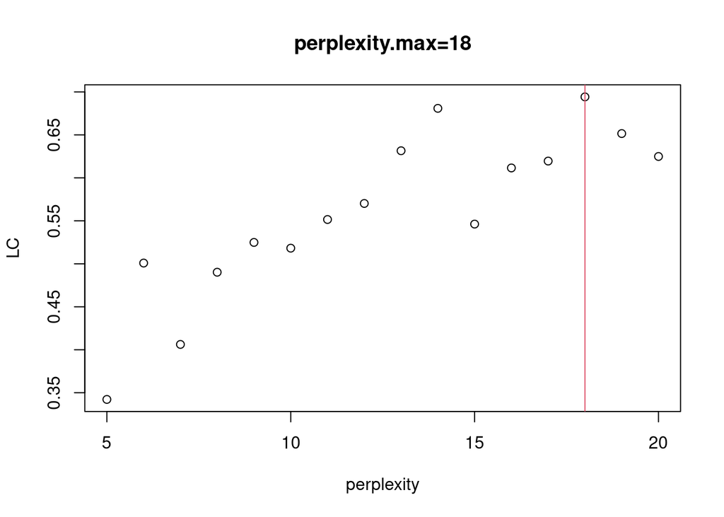

```r
require(Rtsne)
set.seed(4444) # Other seeds give not so nice results: try, for instance (654321) or (1234)

D1 <- dist(XYZ)
q <- 1
Kp <- 10

perplexity <- seq(5,20,by=1) #seq(9,21,by=3)

LC <- numeric(length(perplexity))
Rtsne.k <- vector("list",length(perplexity))

for (i in 1:length(perplexity)){
    Rtsne.k[[i]] <- Rtsne(D1, perplexity=perplexity[i], dims=q,
                          theta=0, pca=FALSE, max_iter = 1000)
    D2.k <- dist(Rtsne.k[[i]]$Y)
    LC[i] <- LCMC(D1,D2.k,Kp)$M.Kp.adj
    #print(c(i,j,LC[i,j]))
}

i.max <- which.max(LC)
perplexity.max <- perplexity[i.max[1]]
Rtsne.max <- Rtsne.k[[i.max]]

plot(perplexity,LC, main=paste0("perplexity.max=",perplexity.max))
abline(v=perplexity[i.max],col=2)
```

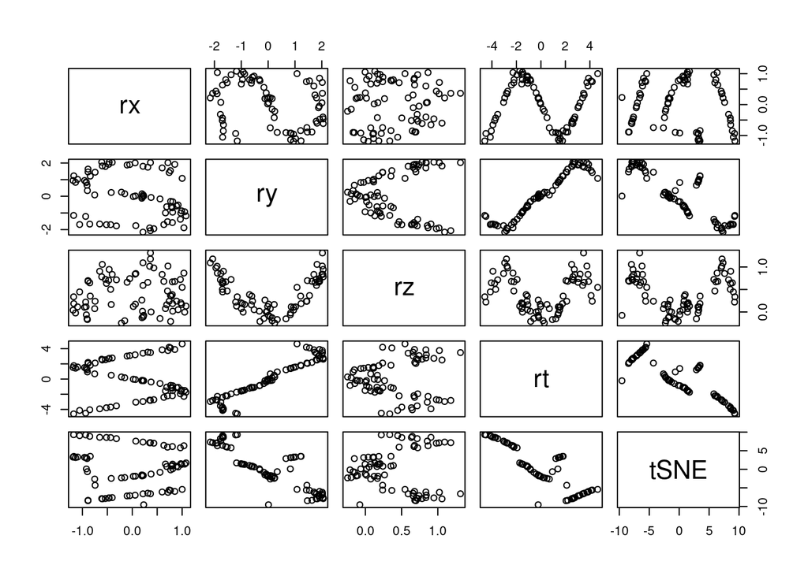

```r
pairs(cbind(XYZ,rt,tSNE=Rtsne.max$Y[,1]))
```

Alternative graphical representations of the t-SNE fit, `Rtsne.max`, can be done using smoothing techniques:

```r
#install.packages("mgcv") # To perform spline smoothing
library(mgcv)

df.xyzts <- as.data.frame(cbind(XYZ,rt,lambda=Rtsne.max$Y[,1]))
names(df.xyzts)
```

```
FALSE [1] "rx"     "ry"     "rz"     "rt"     "lambda"
```

```r
#[1] "rx" "ry" "rz" "rt" "s(lambda)"

smooth.x <- gam(rx~s(lambda), data=df.xyzts)
smooth.y <- gam(ry~s(lambda), data=df.xyzts)
smooth.z <- gam(rz~s(lambda), data=df.xyzts)

summary(smooth.x)
```

```
FALSE
FALSE Family: gaussian
FALSE Link function: identity
FALSE
FALSE Formula:
FALSE rx ~ s(lambda)
FALSE
FALSE Parametric coefficients:
FALSE             Estimate Std. Error t value Pr(>|t|)
FALSE (Intercept)  0.01609    0.04611   0.349    0.728
FALSE
FALSE Approximate significance of smooth terms:
FALSE             edf Ref.df     F p-value
FALSE s(lambda) 8.575  8.948 19.07  <2e-16 ***
FALSE ---
FALSE Signif. codes:  0 '***' 0.001 '**' 0.01 '*' 0.05 '.' 0.1 ' ' 1
FALSE
FALSE R-sq.(adj) =  0.694   Deviance explained = 72.9%
FALSE GCV = 0.18279  Scale est. = 0.15946   n = 75
```

```r
summary(smooth.y)
```

```
FALSE
FALSE Family: gaussian
FALSE Link function: identity
FALSE
FALSE Formula:
FALSE ry ~ s(lambda)
FALSE
FALSE Parametric coefficients:
FALSE             Estimate Std. Error t value Pr(>|t|)
FALSE (Intercept)  0.08838    0.03239   2.729  0.00817 **
FALSE ---
FALSE Signif. codes:  0 '***' 0.001 '**' 0.01 '*' 0.05 '.' 0.1 ' ' 1
FALSE
FALSE Approximate significance of smooth terms:
FALSE             edf Ref.df     F p-value
FALSE s(lambda) 8.846  8.993 184.7  <2e-16 ***
FALSE ---
FALSE Signif. codes:  0 '***' 0.001 '**' 0.01 '*' 0.05 '.' 0.1 ' ' 1
FALSE
FALSE R-sq.(adj) =  0.957   Deviance explained = 96.2%
FALSE GCV = 0.090573  Scale est. = 0.078683  n = 75
```

```r
summary(smooth.z)
```

```
FALSE
FALSE Family: gaussian
FALSE Link function: identity
FALSE
FALSE Formula:
FALSE rz ~ s(lambda)
FALSE
FALSE Parametric coefficients:
FALSE             Estimate Std. Error t value Pr(>|t|)
FALSE (Intercept)  0.40354    0.01895   21.29   <2e-16 ***
FALSE ---
FALSE Signif. codes:  0 '***' 0.001 '**' 0.01 '*' 0.05 '.' 0.1 ' ' 1
FALSE
FALSE Approximate significance of smooth terms:
FALSE             edf Ref.df    F p-value
FALSE s(lambda) 8.541  8.939 40.4  <2e-16 ***
FALSE ---
FALSE Signif. codes:  0 '***' 0.001 '**' 0.01 '*' 0.05 '.' 0.1 ' ' 1
FALSE
FALSE R-sq.(adj) =  0.828   Deviance explained = 84.8%
FALSE GCV = 0.030861  Scale est. = 0.026935  n = 75
```

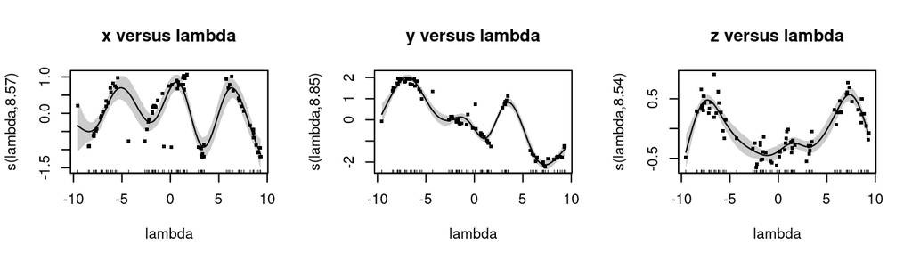

```r
op <- par(mfrow=c(1,3))
plot(smooth.x, residuals=TRUE, shade=TRUE, cex=4, main="x versus lambda")
plot(smooth.y, residuals=TRUE, shade=TRUE, cex=4, main="y versus lambda")
plot(smooth.z, residuals=TRUE, shade=TRUE, cex=4, main="z versus lambda")
```

```r
par(op)
```

Now we do similar plots by ourselves:

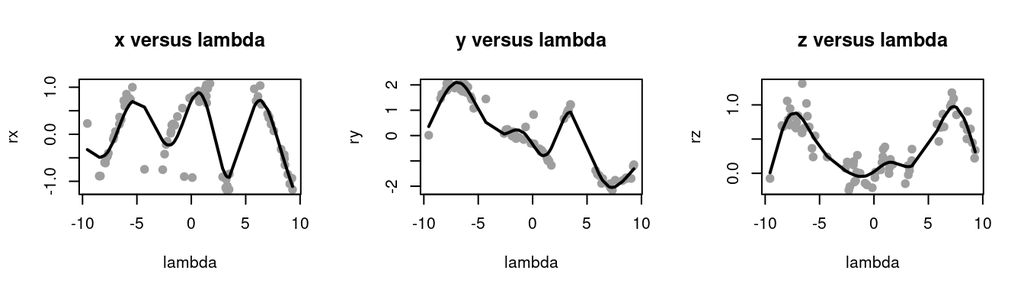

```r
s.x <- smooth.x$fitted.values
s.y <- smooth.y$fitted.values
s.z <- smooth.z$fitted.values
lambda <- Rtsne.max$Y[,1]

ord.lambda <- sort(lambda,index.return=TRUE)$ix

op <- par(mfrow=c(1,3))
plot(lambda, rx, col=8, pch=19, cex=1, main="x versus lambda")
lines(lambda[ord.lambda], s.x[ord.lambda], col=1, lwd=2)
plot(lambda, ry, col=8, pch=19, cex=1, main="y versus lambda")
lines(lambda[ord.lambda], s.y[ord.lambda], col=1, lwd=2)
plot(lambda, rz, col=8, pch=19, cex=1, main="z versus lambda")
lines(lambda[ord.lambda], s.z[ord.lambda], col=1, lwd=2)
```

```r
par(op)
```

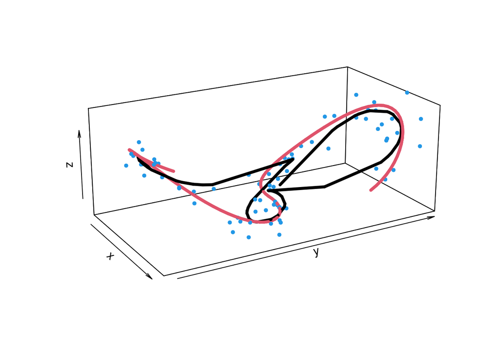

```r
require(plot3D)
lines3D(x,y,z,colvar = NULL,
         phi = 20, theta = 60, r =sqrt(3), d =3, scale=FALSE,
         col=2,lwd=4,as=1,
         xlim=range(rx),ylim=range(ry),zlim=range(rz))
points3D(rx,ry,rz,col=4,pch=19,cex=.6,add=TRUE)
lines3D(s.x[ord.lambda],s.y[ord.lambda],s.z[ord.lambda], col=1, lwd=4, add=TRUE)
```

```r
require(rgl)
points3d(rx,ry,rz,col=4,size=10)
lines3d(x,y,z, col=2,lwd=4)
lines3d(s.x[ord.lambda],s.y[ord.lambda],s.z[ord.lambda], col=1, lwd=4)
```